## Setup

### Load packages

```r
library(ggplot2)
library(dplyr)
library(statsr)
library(BAS)
library(MASS)
library(GGally)
```

### Load data

```r
load("movies.Rdata")
```

## Part 1: Data

We can appreciate that the data is just captured/recollected from the sites Rotten Tomatoes and IMDB. Therefore the data is not random nor controlled, it is just data from the internet. It probably is from a limited group also, since you need to have a computer/digital device, internet, being interest in commenting on does pages, we have no clue from which people that data id gathered, etc. Because of that our analysis need to be taken with a grain of salt. Also, our data cannot be used for causality since we are not manipulating anything is just a recollection of already being data.

With that in mind let’s proceed with our analysis

## Part 2: Data manipulation

We need to create some new variables for conduction our analysis according to the instructions. The variables `feature_film` with levels yes (movies that are feature films) and no; `mpaa_rating_R` with levels yes (movies that are R rated) and no; `oscar_season` with levels yes (if movie is released in November, October, or December) and no; `summer_season` with levels yes (if movie is released in May, June, July, or August) and no.

```r
movies <- mutate(movies,feature_film= ifelse(movies$title_type== "Feature Film", "Yes", "No"))
```

```r
movies <- mutate(movies, mpaa_rating_R=ifelse(movies$mpaa_rating=="R","Yes", "No"))
```

```r
a<- c(11, 10, 12)
movies <- mutate(movies, oscar_season= ifelse((movies$thtr_rel_month==a), "Yes", "No"))
```

```r
b<- c(5, 6, 7, 8)
movies <- mutate(movies, summer_season= ifelse((movies$thtr_rel_month %in% 5) | (movies$thtr_rel_month %in% 6) | (movies$thtr_rel_month %in% 7)| (movies$thtr_rel_month %in% 8), "Yes", "No"))
```

With this simple code using mutate and the ifelse function we have created the variables we needed for our current project. Now let´s continue with our exploration of the data * * *

## Part 3: Exploratory data analysis

```r
str(movies)
```

```
## tibble [651 x 36] (S3: tbl_df/tbl/data.frame)
##  $ title           : chr [1:651] "Filly Brown" "The Dish" "Waiting for Guffman" "The Age of Innocence" ...
##  $ title_type      : Factor w/ 3 levels "Documentary",..: 2 2 2 2 2 1 2 2 1 2 ...
##  $ genre           : Factor w/ 11 levels "Action & Adventure",..: 6 6 4 6 7 5 6 6 5 6 ...
##  $ runtime         : num [1:651] 80 101 84 139 90 78 142 93 88 119 ...
##  $ mpaa_rating     : Factor w/ 6 levels "G","NC-17","PG",..: 5 4 5 3 5 6 4 5 6 6 ...
##  $ studio          : Factor w/ 211 levels "20th Century Fox",..: 91 202 167 34 13 163 147 118 88 84 ...
##  $ thtr_rel_year   : num [1:651] 2013 2001 1996 1993 2004 ...
##  $ thtr_rel_month  : num [1:651] 4 3 8 10 9 1 1 11 9 3 ...
##  $ thtr_rel_day    : num [1:651] 19 14 21 1 10 15 1 8 7 2 ...
##  $ dvd_rel_year    : num [1:651] 2013 2001 2001 2001 2005 ...
##  $ dvd_rel_month   : num [1:651] 7 8 8 11 4 4 2 3 1 8 ...
##  $ dvd_rel_day     : num [1:651] 30 28 21 6 19 20 18 2 21 14 ...
##  $ imdb_rating     : num [1:651] 5.5 7.3 7.6 7.2 5.1 7.8 7.2 5.5 7.5 6.6 ...
##  $ imdb_num_votes  : int [1:651] 899 12285 22381 35096 2386 333 5016 2272 880 12496 ...
```

[output cut: 22 more lines]

From this we can appreciate that some variables are just useless. We see that: all the actor (actor1, actor2, etc) variables, the imdb_url, rt_url, the title,director, probably the oscar nominations/winners, theater/dvd release dates, the studio, mpaa_rating (correlation with our new variable), the ratings, genre (correlation with our new variable), are all useless.

This leaves us with a small set relevant variables: runtime, feature_film, mpaa_rating_R, oscar_season, summer_season, critics_score, and audience_score.

Now let’s see how this data is distributed:

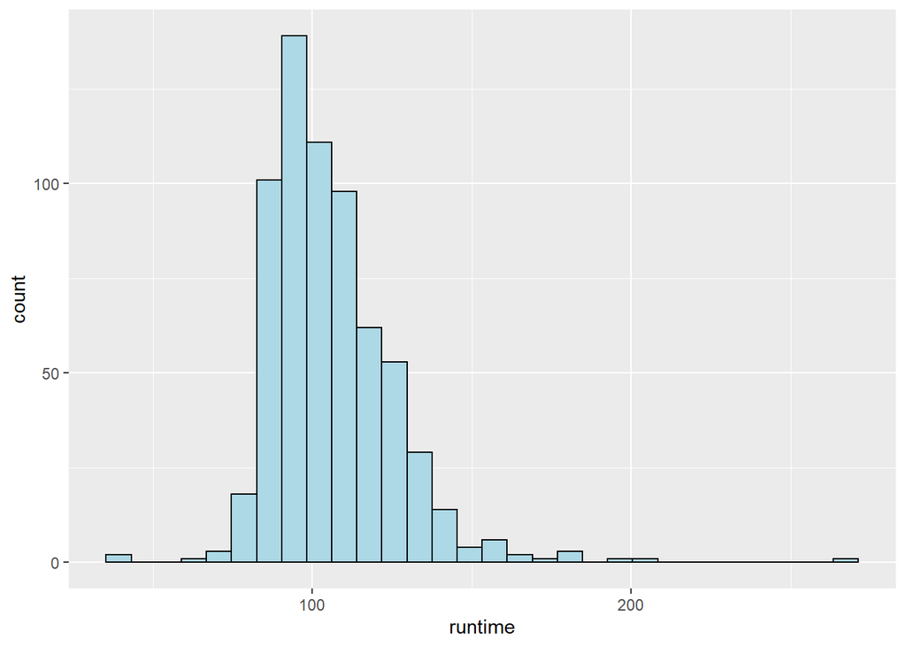

```r
ggplot(data=movies, aes(x=runtime))+
  geom_histogram(color= "black", fill="light blue")
```

It seems to be nearly normal, but it seems that there is one particular movie that is way up there near the 300 min!

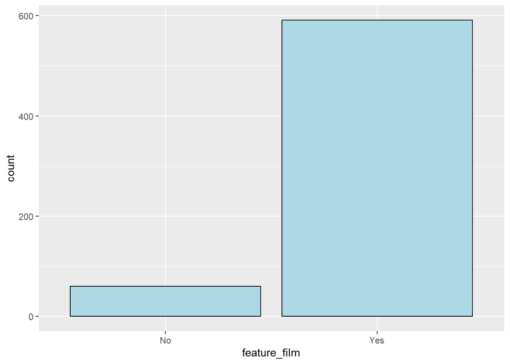

```r
ggplot(data=movies, aes(x=feature_film))+
  geom_bar(color="black", fill="light blue")
```

We can also appreciate that there is way more feature_films than does that don’t. Which makes sense since short films are not not what we know Hollywood for.

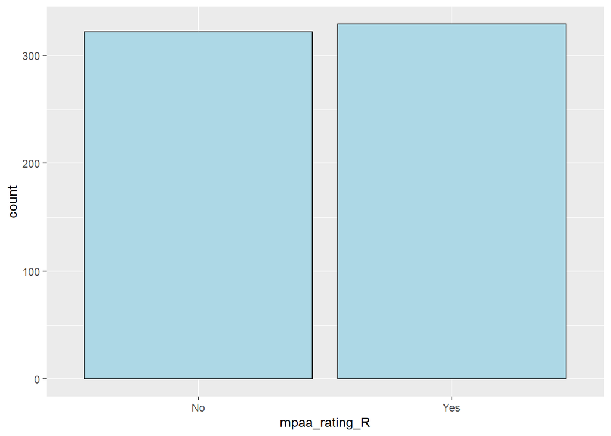

```r
ggplot(data = movies, aes(x=mpaa_rating_R))+
  geom_bar(color="black", fill="light blue")
```

This is very interesting since I would have guess that the R rating was the less, since that seems to be more commercial since more persons can watch it. Nontheless we appreciate that it is even in comparisson to the other classifications!

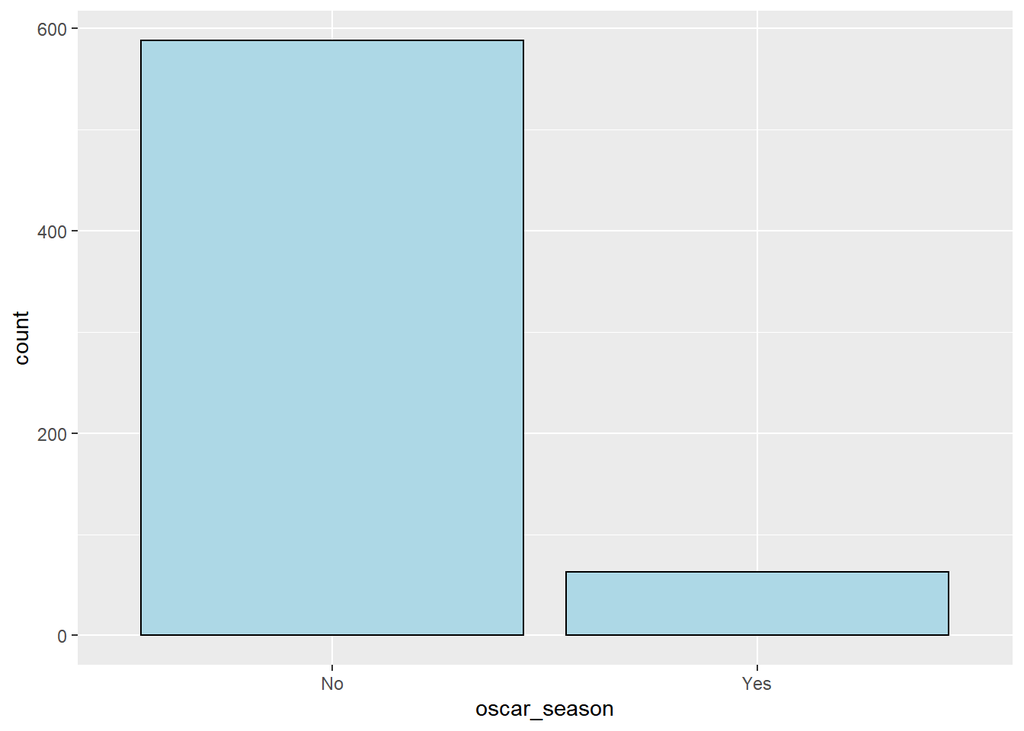

```r
ggplot(data=movies, aes(x=oscar_season))+
  geom_bar(color="black", fill="light blue")
```

This probably means that producers are not here for winning Oscars but for other purposes.

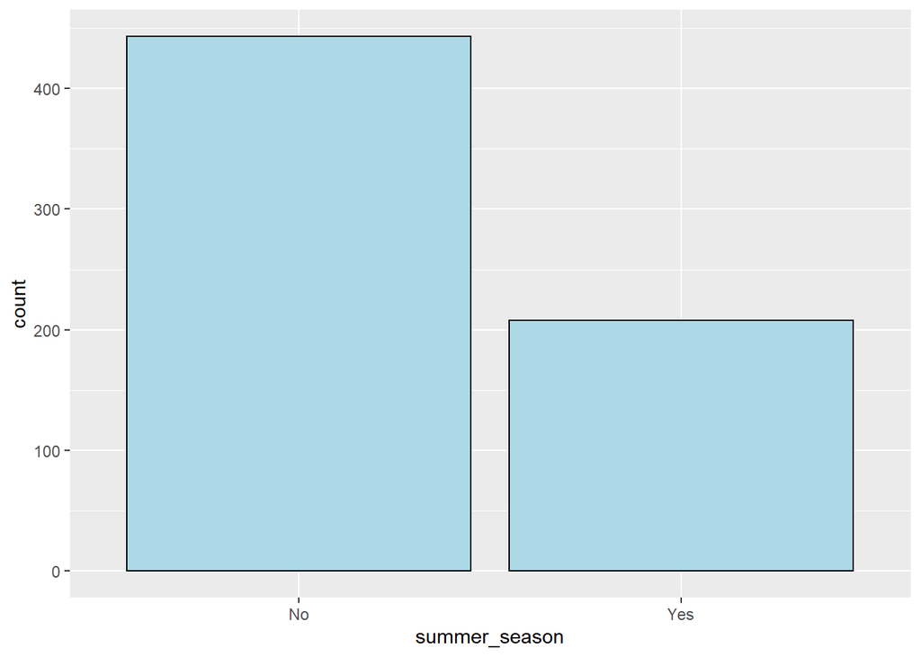

```r
ggplot(data=movies, aes(x=summer_season))+
  geom_bar(color="black", fill="light blue")
```

This implies that neither is summer season THE season, therefore we can assume that the first third of the year is actually THE season.

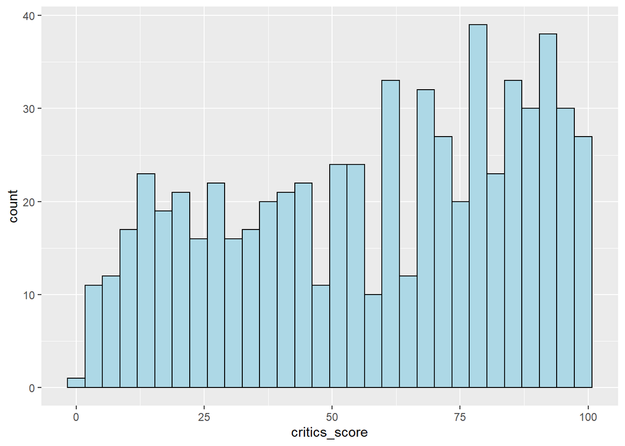

```r
ggplot(data = movies, aes(x=critics_score))+
  geom_histogram(color="black", fill="light blue")
```

This just seem to be all over the place, or that the critics are actually very impartial and that lower nor higher scores are the rule.

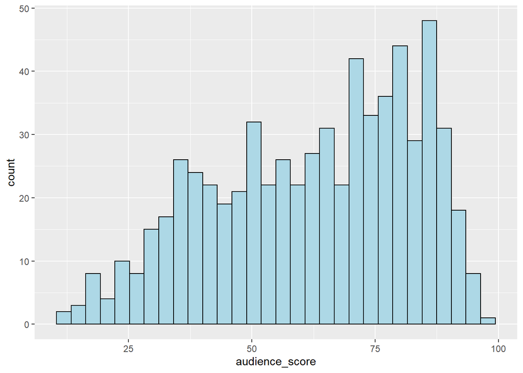

```r
ggplot(data=movies, aes(x=audience_score))+
  geom_histogram(color="black", fill="light blue")
```

Contrary to our critics this seems a little bit tilted to the right, or that they tend to be a bit more generous with their score.

```r
summary(movies$runtime)
```

```
##    Min. 1st Qu.  Median    Mean 3rd Qu.    Max.    NA's
##    39.0    92.0   103.0   105.8   115.8   267.0       1
```

```r
summary(movies$critics_score)
```

```
##    Min. 1st Qu.  Median    Mean 3rd Qu.    Max.
##    1.00   33.00   61.00   57.69   83.00  100.00
```

```r
summary(movies$audience_score)
```

```
##    Min. 1st Qu.  Median    Mean 3rd Qu.    Max.
##   11.00   46.00   65.00   62.36   80.00   97.00
```

We can appreciate more clearly what we saw earlier, that the movies are not short films since the mean duration is 105.8 min, and that the critics (mean=62.32 and 57.69) have lower and more variable(33 to 83 and 46 to 80) scores than audience.

## Part 4: Modeling

First let’s try the non informative model which is just the same as the least square model or frequentist regression,

```r
movies <- na.omit(movies)
movies_lm <-lm(audience_score~ runtime + feature_film + mpaa_rating_R +
                  oscar_season + summer_season + critics_score, data = movies)

summary(movies_lm)
```

```
##
## Call:
## lm(formula = audience_score ~ runtime + feature_film + mpaa_rating_R +
##     oscar_season + summer_season + critics_score, data = movies)
##
## Residuals:
##     Min      1Q  Median      3Q     Max
## -36.068  -9.616   0.597   9.923  41.703
##
## Coefficients:
##                  Estimate Std. Error t value Pr(>|t|)
## (Intercept)      33.14410    3.96937   8.350 4.57e-16 ***
## runtime           0.07261    0.03134   2.317  0.02085 *
## feature_filmYes  -6.48973    2.37777  -2.729  0.00653 **
## mpaa_rating_RYes  0.41167    1.17050   0.352  0.72518
## oscar_seasonYes   2.80645    2.03059   1.382  0.16745
## summer_seasonYes -0.54256    1.26388  -0.429  0.66787
## critics_score     0.47073    0.02209  21.311  < 2e-16 ***
## ---
## Signif. codes:  0 '***' 0.001 '**' 0.01 '*' 0.05 '.' 0.1 ' ' 1
##
## Residual standard error: 14.28 on 612 degrees of freedom
## Multiple R-squared:  0.5042, Adjusted R-squared:  0.4994
## F-statistic: 103.7 on 6 and 612 DF,  p-value: < 2.2e-16
```

```r
n<- nrow(movies)
stepAIC(movies_lm, k=log(n))
```

```
## Start:  AIC=3329.34
## audience_score ~ runtime + feature_film + mpaa_rating_R + oscar_season +
##     summer_season + critics_score
##
##                 Df Sum of Sq    RSS    AIC
## - mpaa_rating_R  1        25 124765 3323.0
## - summer_season  1        38 124777 3323.1
## - oscar_season   1       389 125129 3324.8
## - runtime        1      1094 125834 3328.3
## <none>                       124740 3329.3
## - feature_film   1      1518 126258 3330.4
## - critics_score  1     92570 217310 3666.5
##
## Step:  AIC=3323.03
## audience_score ~ runtime + feature_film + oscar_season + summer_season +
##     critics_score
##
##                 Df Sum of Sq    RSS    AIC
## - summer_season  1        40 124805 3316.8
## - oscar_season   1       382 125147 3318.5
## - runtime        1      1087 125852 3322.0
## <none>                       124765 3323.0
## - feature_film   1      1499 126264 3324.0
## - critics_score  1     93491 218256 3662.8
##
## Step:  AIC=3316.8
## audience_score ~ runtime + feature_film + oscar_season + critics_score
##
##                 Df Sum of Sq    RSS    AIC
## - oscar_season   1       460 125265 3312.7
## - runtime        1      1114 125919 3315.9
## <none>                       124805 3316.8
## - feature_film   1      1542 126347 3318.0
## - critics_score  1     93602 218407 3656.8
##
## Step:  AIC=3312.65
## audience_score ~ runtime + feature_film + critics_score
##
##                 Df Sum of Sq    RSS    AIC
## <none>                       125265 3312.7
## - runtime        1      1370 126635 3313.0
## - feature_film   1      1484 126749 3313.5
## - critics_score  1     93493 218757 3651.3
```

```
##
## Call:
## lm(formula = audience_score ~ runtime + feature_film + critics_score,
##     data = movies)
##
## Coefficients:
##     (Intercept)          runtime  feature_filmYes    critics_score
##        32.45887          0.08019         -6.27946          0.47050
```

According to our backwards model selection using BIC we find that the best model is: audience_score ~ runtime + feature_film + critics_score. We also need to see if the diagnostic plots say if this model is correct or not.

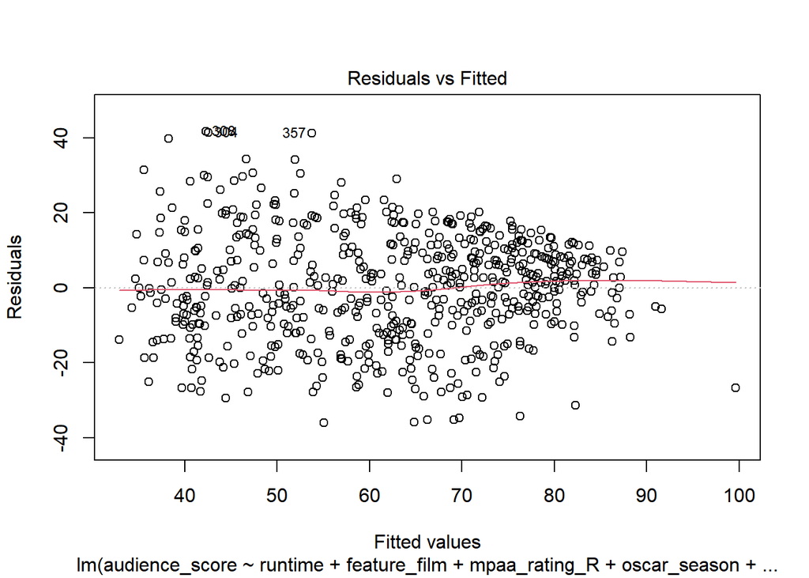

```r
plot(movies_lm, which = 1)
```

It seems that homocedasticity is more or less correct

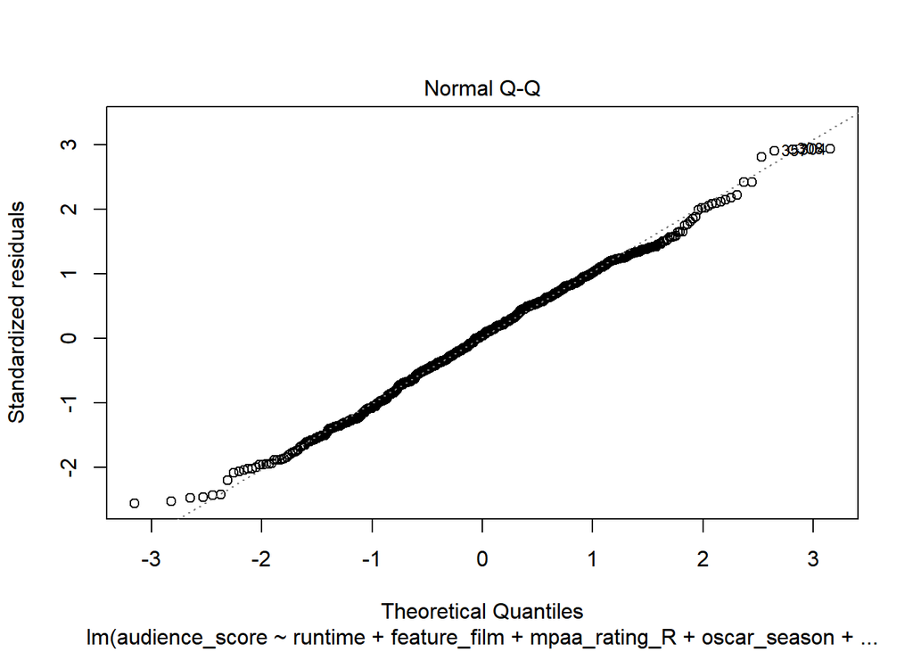

```r
plot(movies_lm, which = 2)
```

Also residuals seem to be quite normal except for some outliers but overall seems great.

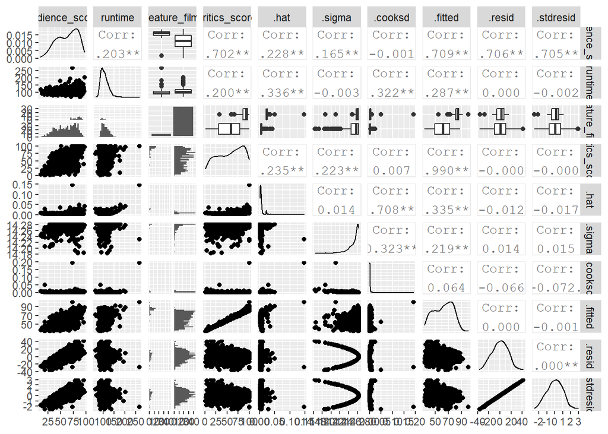

```r
model_afterBIC <- lm(audience_score ~ runtime + feature_film + critics_score, data=movies )
ggpairs(model_afterBIC)
```

So, apparently there is no significant colinearity but a mild .2 between critics score and runtime.

Now let’s model this data using the BAS and the BMA to see how model averaging changes our view

```r
movies <- na.omit(movies)
movies_lm_BMA <- bas.lm(audience_score~ runtime + feature_film + mpaa_rating_R+
                  oscar_season + summer_season + critics_score , data = movies, prior = "BIC", modelprior = uniform())

movies_lm_BMA
```

```
##
## Call:
## bas.lm(formula = audience_score ~ runtime + feature_film + mpaa_rating_R +
##     oscar_season + summer_season + critics_score, data = movies,
##     prior = "BIC", modelprior = uniform())
##
##
##  Marginal Posterior Inclusion Probabilities:
##        Intercept           runtime   feature_filmYes  mpaa_rating_RYes
##          1.00000           0.41217           0.48850           0.03979
##  oscar_seasonYes  summer_seasonYes     critics_score
##          0.13977           0.05868           1.00000
```

```r
summary(movies_lm_BMA)
```

```
##                  P(B != 0 | Y)    model 1       model 2       model 3
## Intercept           1.00000000     1.0000     1.0000000     1.0000000
## runtime             0.41216617     0.0000     1.0000000     0.0000000
## feature_filmYes     0.48849874     0.0000     1.0000000     1.0000000
## mpaa_rating_RYes    0.03978603     0.0000     0.0000000     0.0000000
## oscar_seasonYes     0.13977266     0.0000     0.0000000     0.0000000
## summer_seasonYes    0.05868197     0.0000     0.0000000     0.0000000
## critics_score       1.00000000     1.0000     1.0000000     1.0000000
## BF                          NA     1.0000     0.7621122     0.6541342
## PostProbs                   NA     0.2665     0.2031000     0.1743000
## R2                          NA     0.4921     0.5021000     0.4967000
## dim                         NA     2.0000     4.0000000     3.0000000
## logmarg                     NA -3645.5528 -3645.8244842 -3645.9772654
##                        model 4       model 5
## Intercept            1.0000000     1.0000000
## runtime              1.0000000     0.0000000
## feature_filmYes      0.0000000     0.0000000
## mpaa_rating_RYes     0.0000000     0.0000000
## oscar_seasonYes      0.0000000     1.0000000
## summer_seasonYes     0.0000000     0.0000000
## critics_score        1.0000000     1.0000000
## BF                   0.4951308     0.1792875
## PostProbs            0.1320000     0.0478000
## R2                   0.4962000     0.4946000
## dim                  3.0000000     3.0000000
## logmarg          -3646.2557560 -3647.2715870
```

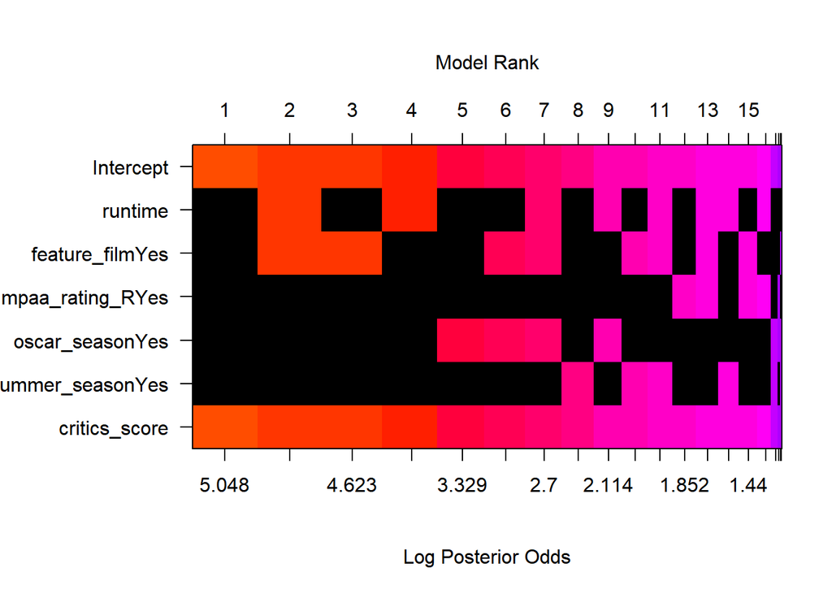

```r
image(movies_lm_BMA, rotate=F)
```

```r
coefs<-coef(movies_lm_BMA)
confint(coefs)
```

```
##                          2.5%       97.5%         beta
## Intercept        61.071851554 63.35437923 62.210016155
## runtime           0.000000000  0.11448368  0.030899553
## feature_filmYes  -9.003786088  0.00000000 -2.888815141
## mpaa_rating_RYes  0.000000000  0.00000000  0.002370235
## oscar_seasonYes  -0.008129143  4.48646287  0.463640701
## summer_seasonYes -0.490588445  0.09652811 -0.067563028
## critics_score     0.440432820  0.53506732  0.487067942
## attr(,"Probability")
## [1] 0.95
## attr(,"class")
## [1] "confint.bas"
```

## Part 5: Prediction

We need to generate a new data frame for predicting using our model after the BIC backward selection. Also let use the model that only uses the critics score to see how it does the job.

```r
data_for_BICmodel <- data.frame(runtime= 100, feature_film= "Yes", critics_score=100)

predict.lm(model_afterBIC, data_for_BICmodel, interval = "prediction")
```

```
##        fit      lwr      upr
## 1 81.24772 53.11886 109.3766
```

Therefore we expect that our audience would rate this movie with a 81.24772 but that a credible interval for this prediction is about (53.11886, 109.3766).

```r
data_for_BMAmodel <- data.frame(critics_score=100)
lm_according_to_BF <- lm(audience_score~ critics_score, data=movies)
predict.lm(lm_according_to_BF, data_for_BMAmodel, interval = "prediction")
```

```
##        fit      lwr      upr
## 1 83.48316 55.14748 111.8188
```

We see that the models are almost as good at predicting the audience score with this model predicting an audience score of 83.48316 when critics score of 100 with a credible interval of (55.14748, 111.8188) * * *

## Part 6: Conclusion

This project was very interesting to do I learned a lot about presenting the uncertainty about the models and that model selection is not a black and white thing. Also, sometimes less complex models may be better or equally good as more complex models.

Now, we were able to appreciate that the models predicted similar scores for audiences when we used the model based on the BIC or on our BMA. Therefore it seems that our audiences are influenced by our critics rating of the movies. Which makes sense since we normally are influenced by what experts think about. Nonetheless we need to be cautious with this interpretation since, as we noticed before, this is not an experiment and we cannot infere causality nor this results can be generalized to other populations (e.g audience of Bollywood).